# BS 1515 Lecture 3: Univariate Calculus, Differentiation, and Integration

Sergey V. Popov

2026-09-21

# Last time

We defined

- sets: collection of things
- spaces: set of “everything”
- functions: rule of going from one set to another
- ordering: function from set-squared to $\{0,1\}$
- metric: function from set-squared to $\mathbb{R}_{+}$
- (in)equalities: implicitly defined sets
- systems of (in)equalities: intersection of implicitly defined sets

Today

- functions defined on $\mathbb{R}\rightarrow \mathbb{R}$
- derivatives
- integrals

# Functions

Any rule that assigns to each element of the *domain* exactly one element of the *codomain*.

- Examples: $y(x)=x^2$; metric; preference.
- Graph of $f$: the set $\{(x,y): y=f(x)\}$. Subgraph (hypograph): everything on or below the graph. Supergraph (epigraph): everything on or above the graph.
- If you have multiple values for the same *argument*, this is *correspondence*, not a function!
- If you don’t have a value for a certain argument, the function is *not well-defined*.

# Example

Demand: $Q(p):\mathbb{R}_{+}\rightarrow \mathbb{R}_{+}$.

Inverse demand: $P(q)=Q^{-1}(q)$, the $p$ such that $Q(p)=q$ (unique if demand is strictly decreasing).

Total revenue: $TR(q)=q \cdot P(q)$.

Total cost: $TC(q)=F+VC(q):\mathbb{R}_{+}\rightarrow \mathbb{R}_{+}$.

Profit: $\Pi(q)=TR(q)-TC(q)$.

How would we choose output?

# What Kind of Functions Are There

*Continuous*: a small change, left or right, does not change the value much.

*Strictly increasing*: $x_1>x_2 \Rightarrow f(x_1)>f(x_2)$. *Strictly decreasing* is the opposite. *Monotone* means either increasing or decreasing.

*Weakly* increasing: $x_1>x_2 \Rightarrow f(x_1)\geq f(x_2)$.

Demand: probably decreasing? If not strictly decreasing, hard to invert.

Continuous? Maybe…

Total cost: probably increasing?

# Plot Functions

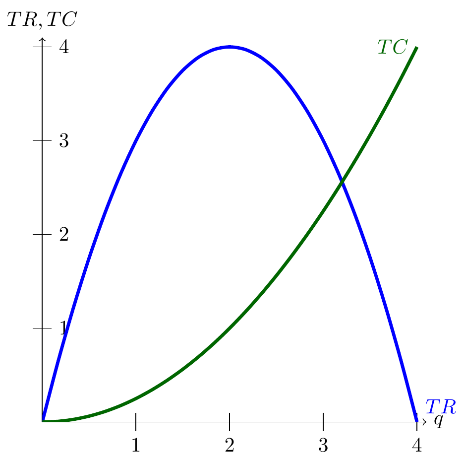

# Calculus

*Infinitesimal calculus* is about studying small changes. Differential calculus: study what changes if we have a small change in the argument. Integral calculus: how do these changes accumulate.

*Derivative* of a function at a point is the slope of the tangent line to its graph at that point.

*Integral* of a function is the *signed* area between its graph and the horizontal axis: area above the axis counts as positive, area below counts as negative.

Based on the concept of *limit*. A *sequence* $\{a_i\}$ is an ordered list $a_1,a_2,a_3,\ldots$ indexed by $i\in\{1,2,\ldots\}$ (values may repeat).

Sequences might have limit points. $A$ is a *limit point* of $\{a_i\}$ if for every $\varepsilon>0$, $a_i\in B_\varepsilon(A)$ for infinitely many indices $i$.

Point $A$ is a *limit* of $\{a_i\}$ if for every $\varepsilon>0$, $a_i\notin B_\varepsilon(A)$ for only finitely many indices $i$.

A sequence is decreasing if $\forall i\geq 1, a_{i+1}\leq a_i$.

# Limit Exercises

Prove: a decreasing bounded sequence has a limit.

Prove: an increasing bounded sequence has a limit.

Prove: $\{1,0,1,0,1,0,\ldots\}$ does not have a limit.

Prove: $\left\{\frac{1}{1},\frac{1}{2},\frac{1}{3},\ldots\right\}$ has a limit.

Useful to know:

- $\lim (a_n+b_n)=\lim a_n+\lim b_n$ as long as all exist
- $\lim c\cdot a_n=c\cdot \lim a_n$

Prove: if $f()$ is continuous, $\lim f(a_n)=f(\lim a_n)$: continuous functions preserve convergence.

# Derivative

$$f'(x)=\lim_{\Delta\rightarrow 0}
\frac{f(x+\Delta)-f(x)}{\Delta}$$

- as $\Delta\rightarrow 0$: take every $\Delta_n \rightarrow 0,\Delta_n \not =0$
- your $\frac{f(x+\Delta_n)-f(x)}{\Delta_n}$ must have the same limit, denoted by $f'(x)$.

Example: $f(x)=x$ - what’s the limit?

What about $f(x)=x^2$?

What about $f(x)=x^3$?

Prove: There is no derivative for $f(x)=|x|$ at $x=0$.

Prove: $(\sqrt{x})'=\frac{1}{2}\frac{1}{\sqrt{x}}$ using the definition of the derivative (not the power formula).

# Product of functions

Imagine you know $f'(x)$ and $g'(x)$ and you need to find the derivative of $f(x)g(x)$.

$$\left(f(x)g(x)\right)'=f'(x)g(x)+g'(x)f(x)$$

Prove: You know $x'=1$ and $(x^{n})'=nx^{n-1}$ for integer $n\geq 1$. Prove that $(x^{n+1})'=(n+1)x^{n}$.

Prove: $(f(x)g(x)h(x))'=f'(x)g(x)h(x)+f(x)g'(x)h(x)+f(x)g(x)h'(x)$.

Note that if you take $g(x)=1/f(x)$, you have $f(x)g(x)=1$.

Prove: $(1/f(x))'=\frac{-f'(x)}{(f(x))^2}$. Do you need an assumption on $f(x)$?

# Composition of functions

Imagine you have $g(f(x))$, and you know $f'(x)$ and $g'(y)$. Then

$$\left(g(f(x))
\right)'=g'(f(x))f'(x).$$

Prove using the chain rule: $\left(\frac{1}{f(x)}\right)'=-\frac{1}{(f(x))^2}f'(x)$

Prove: $\left(\frac{g(x)}{f(x)}\right)'=\frac{f(x)g'(x)-g(x)f'(x)}{(f(x))^2}$

Remember: $g(y)$ is an inverse of $y=f(x)$ if $g(f(x))=x$.

Prove: $g'(y)=\frac{1}{f'(g(y))}$.

Prove: $(\sqrt{x})'=\frac{1}{2}\frac{1}{\sqrt{x}}$ using the inverse function derivative formula.

Prove: $(e^x)'=e^x$ knowing $e=\lim_{t\rightarrow 0} \left(1+t\right)^{1/t}$.

Prove: $(a^x)'=\ln a\cdot a^x$.

Prove: $(\ln x)'=1/x$ using the inverse function derivative formula.

# Example

$$TR(q)=q\cdot (4-q), TC(q)=q^2/4
\Rightarrow \Pi(q)=4q-q^2-q^2/4.$$

Imagine you are at an (interior) optimal point. What should be the derivative of the profit? Zero!

- If it is positive, produce a bit more, increase profits!
- If it is negative, produce a bit less, increase profits!

$\Pi'(q)=4-5/2q^* =0$ so $q^*=8/5.$

We will expand on optimization next week.

# Implicit Function Theorem

Suppose $f(x^*,y^*)=0$, but we can’t solve $f(x,y)=0$ explicitly for $y$. ($f'_x$ and $f'_y$ denote derivatives with respect to one variable, holding the other fixed.) As long as $f'_y(x^*,y^*)\neq 0$ and the derivatives are continuous, there is a function $\phi(x)$, defined near $x^*$, such that $f(x,\phi(x))=0$ and $y^*=\phi(x^*)$.

Example: let $f(x,y)=\sqrt{x^2+y^2}-1$. Then there are two solutions at $x^*=1/2$, one is $y^*=\frac{\sqrt{3}}{2}$ and another at $y^*=\frac{-\sqrt{3}}{2}$, so there is no *function* that would tell what happens to the solution if we change $x$. But there is a function near $(1/2,\sqrt{3}/2)$ and another near $(1/2,-\sqrt{3}/2)$.

For such a $\phi(x)$, it should work that $f(x,\phi(x))=0$. Take a derivative with respect to $x$ of both sides:
$$f'_x(x,\phi(x))+f'_y(x,\phi(x))\phi'(x)=0,$$
so $\phi'(x)=-\frac{f'_x(x,\phi(x))}{f'_y(x,\phi(x))}$. Since the right-hand side is continuous, this differential equation has a solution.

At $x^*=1$, $y^*=0$ we have $f'_y=0$, and there is no such function: for $x$ slightly above 1 there is no solution, and for $x$ slightly below 1 there are two.

# Integrals

Differentiation is going from $F(x)$ to the *local change* $f(x)=F'(x)$. Integration is going from local change to total, from $f(x)$ to $F(x)$ such that $F'(x)=f(x)$.

Example: speed as a function of time. Derivative is acceleration; integral is distance traveled.

*Indefinite* integral is $\int f(x) dx$: defined up to a constant. *Definite* integral has limits: $\int_a^b f(x) dx$. *Improper* might have an infinity on one of the sides.

Example: if $MC(q)=a+bq$, $TC(q)=aq+\frac{b}{2} q^2+c$ — fixed costs are impossible to deduce from MC!

# Rules for integrals

$$\int \left(af(x)+bg(x)\right) dx = a
\int f(x) dx+b \int g(x) dx,$$

$$\int x^n dx=\frac{1}{n+1} x^{n+1}+C,
n\not =-1.$$

$$\int 1/x dx=\ln |x| +C.$$

$$\int e^x dx=e^x +C.$$

$$\int a^x dx=\frac{1}{\ln a}a^x +C,
a>0, a\not =1.$$

# Integration by Substitution

$$\int e^x \sqrt{3e^x+2} dx$$

Looks scary? but note $(3e^x+2)'=3e^x$. So let $y=3e^x+2$ then $dy=3e^x dx$ and the integral can be rewritten as

$$\int \frac{1}{3} \sqrt{y}
dy$$

which is much easier.

# Integration by Parts

Observe that
$$(u(x)v(x))'=u'(x)v(x)+v'(x)u(x)$$

so if you have to find $\int u'(x)v(x) dx$ you can use
$$\int u'(x)v(x)
dx=u(x)v(x)+C- \int v'(x) u(x) dx$$

Example:

$$\int \frac{\ln (x)}{x^2}dx$$

Observe that $\ln'(x)=1/x$ so let $u'(x)=\frac{1}{x^2}$ and $v(x)=\ln(x)$, then
$$u(x)=-1/x, v'(x)=1/x$$
and
$$\int \frac{\ln
(x)}{x^2}dx=\ln(x)\frac{-1}{x}+C-\int
\frac{-1}{x}\frac{1}{x}dx=-\frac{\ln (x)+1}{x}+C$$

# Examples

Consider a sphere of radius $R$. What is the volume of this sphere?

Answer: if we slice it by circles, each circle has an area of $\pi r^2$ for some r. What kind of $r$s do we see? Draw the sphere around $0$, take $x\in [-R,R]$. Take the set $\{(x,y,z)|x=x_0,x^2+y^2+z^2\leq R^2\}$; it’s a disk of radius $r=\sqrt{R^2-x_0^2}$. Let us add these disks together as a function of x:
$$\int_{-R}^R \pi (R^2-x^2) dx$$
The indefinite integral is $\pi (R^2 x-x^3/3)+C$; taken from $-R$ to $R$ you get
$$\pi
(\frac{2}{3}R^3-(-\frac{2}{3}R^3))=\frac{4}{3}\pi R^3.$$

# Useful Ideas

Continuous functions on closed intervals are integrable.

$$\int_a^b f(x) dx=
F(b)-F(a).$$

$$\left(\int_a^b f(x)
dx\right)'_b=F'(b)=f(b).$$

$$\left(\int_a^b f(x)
dx\right)'_a=-F'(a)=-f(a).$$

$$\left(\int_a^b f(t,x)
dx\right)'_t=\int_a^b f'_t(t,x)dx.$$

All of these need technical assumptions but if (a) your functions are continuous and (b) you are on an interval, you should be fine.

# Summary for Today

- Derivatives: a rate of change in a function
- Integrals: a sum over values of the function
- We will be using them for optimization next week